# Spotify Podcasts vs. Audio Features: Statistical Testing

Lara Karacasu & Quinn Booth

2023-05-01

## Data Preparation

```r
# Read in CSV
data1 <- read.csv(file = "C:/Users/larak/Downloads/refined_metadata_v2.3.csv", header = T, stringsAsFactors = T)
data1 <- as_tibble(data1)

# Convert audio feature columns to double type
data1 <- data1 %>%
  mutate_at(c(13:100), as.character) %>%
  mutate_at(c(13:100), as.double)

# Replace empty string factor
levels(data1$apple_category)[1] <- "Not specified"

# Print head of data
head(data1)
```

```
## # A tibble: 6 × 100
##       X show_name      episode_name episode_date rss_link apple_link apple_stars
##   <int> <fct>          <fct>        <fct>        <fct>    <fct>            <dbl>
## 1     0 Kop On! A Liv… "[\"episode… ['2-26-2019… https:/… https://p…         4.5
## 2     1 2 Massage The… "['creating… ['5-14-2019… https:/… https://p…         5
## 3     2 2. Bundesliga… "['2. bunde… ['12-04-201… https:/… https://p…         4.9
## 4     3 2MinuteTennis… "['episode … ['7-13-2019… https:/… https://p…         5
## 5     4 4th & Gold Po… "[\"murphy'… ['9-23-2019… https:/… https://p…         4.7
## 6     5 76ers Podcast… "['rewind v… ['10-09-201… https:/… https://p…         4.6
## # ℹ 93 more variables: apple_ratings <int>, apple_category <fct>,
## #   show_filename_prefix <fct>, episode_filename_prefix <fct>, duration <fct>,
## #   F0semitoneFrom27.5Hz_sma3nz_amean <dbl>,
## #   F0semitoneFrom27.5Hz_sma3nz_stddevNorm <dbl>,
## #   F0semitoneFrom27.5Hz_sma3nz_percentile20.0 <dbl>,
## #   F0semitoneFrom27.5Hz_sma3nz_percentile50.0 <dbl>,
## #   F0semitoneFrom27.5Hz_sma3nz_percentile80.0 <dbl>, …
```

## Grouping by Number of Ratings (for t-tests)

```r
high_ratings <- quantile(data1$apple_ratings, 0.90, na.rm = TRUE)
low_ratings <- quantile(data1$apple_ratings, 0.10, na.rm = TRUE)

median_ratings = median(data1$apple_ratings, na.rm = TRUE)

ratings_success_median <- as.factor(case_when(
    data1$apple_ratings < median_ratings ~ "low",
    data1$apple_ratings > median_ratings ~ "high",
    TRUE ~ "medium"
  ))

ratings_success_quantile <- as.factor(case_when(
    data1$apple_ratings <= low_ratings ~ "low",
    data1$apple_ratings >= high_ratings ~ "high",
    TRUE ~ "medium"
  ))

data2 <- data1 %>%
  mutate(data1, ratings_success_median) %>%
  mutate(data1, ratings_success_quantile) %>%
  relocate(ratings_success_median, .after = apple_ratings) %>%
  relocate(ratings_success_quantile, .after = ratings_success_median)

data3 <- data2 %>%
  filter(ratings_success_median == "low" | ratings_success_median == "high") %>%
  drop_na()
print(count(data3))
```

```
## # A tibble: 1 × 1
##       n
##   <int>
## 1   398
```

```r
data5 <- data2 %>%
  filter(ratings_success_quantile == "low" | ratings_success_quantile == "high") %>%
  drop_na()
print(count(data5))
```

```
## # A tibble: 1 × 1
##       n
##   <int>
## 1    67
```

## Grouping by Star Ratings (for t-tests)

```r
high_stars <- quantile(data1$apple_stars, 0.90, na.rm = TRUE)
low_stars <- quantile(data1$apple_stars, 0.10, na.rm = TRUE)

median_stars = median(data1$apple_stars, na.rm = TRUE)

stars_success_median <- as.factor(case_when(
    data1$apple_stars < median_stars ~ "low",
    data1$apple_stars > median_stars ~ "high",
    TRUE ~ "medium"
  ))

stars_success_quantile <- as.factor(case_when(
    data1$apple_stars <= low_stars ~ "low",
    data1$apple_stars >= high_stars ~ "high",
    TRUE ~ "medium"
  ))

data2 <- data1 %>%
  mutate(data1, stars_success_median) %>%
  mutate(data1, stars_success_quantile) %>%
  relocate(stars_success_median, .after = apple_ratings) %>%
  relocate(stars_success_quantile, .after = stars_success_median)

data4 <- data2 %>%
  filter(stars_success_median == "low" | stars_success_median == "high") %>%
  drop_na()
print(count(data4))
```

```
## # A tibble: 1 × 1
##       n
##   <int>
## 1   326
```

```r
data6 <- data2 %>%
  filter(stars_success_quantile == "low" | stars_success_quantile == "high") %>%
  drop_na()
print(count(data6))
```

```
## # A tibble: 1 × 1
##       n
##   <int>
## 1   101
```

## Statistical Testing

We are focusing on five audio features: fundamental frequency, jitter, shimmer, HNR, and loudness. In our dataset, these are modeled by the following, respectively: F0semitoneFrom27.5Hz_sma3nz_amean, jitterLocal_sma3nz_amean, shimmerLocaldB_sma3nz_amean, HNRdBACF_sma3nz_amean, and loudness_sma3_amean We also have two independent variables: average rating and average engagement. In our dataset, these are modeled by the following, respectively: apple_stars and apple_ratings.

### Hypothesis 1

Podcasts with higher star ratings will differ significantly from podcasts with lower star ratings across numerous acoustic features.

### Hypothesis 2

Podcasts with more raters will differ significantly from podcasts with fewer raters across numerous acoustic features.

# Testing against number of ratings

```r
# t-tests separated by median

# conduct t-tests for each acoustic feature comparing high and low success groups
ttest_fundamental_frequency <- t.test(data3$F0semitoneFrom27.5Hz_sma3nz_amean ~ data3$ratings_success_median, alternative = "two.sided")
ttest_jitter <- t.test(data3$jitterLocal_sma3nz_amean ~ data3$ratings_success_median, alternative = "two.sided")
ttest_shimmer <- t.test(data3$shimmerLocaldB_sma3nz_amean ~ data3$ratings_success_median, alternative = "two.sided")
ttest_HNR <- t.test(data3$HNRdBACF_sma3nz_amean ~ data3$ratings_success_median, alternative = "two.sided")
ttest_loudness <- t.test(data3$loudness_sma3_amean ~ data3$ratings_success_median, alternative = "two.sided")

# perform Benjamini-Hochberg correction
pvalues <- c(ttest_fundamental_frequency$p.value, ttest_jitter$p.value, ttest_shimmer$p.value, ttest_HNR$p.value, ttest_loudness$p.value)
adjusted_pvalues <- p.adjust(pvalues, method = "BH")

# print the p-values and adjusted p-values for each t-test

print("SEPARATED BY MEDIAN")
```

```
## [1] "SEPARATED BY MEDIAN"
```

```r
print(paste("T-test for fundamental frequency: p-value =", ttest_fundamental_frequency$p.value, ", adjusted p-value =", adjusted_pvalues[1]))
```

```
## [1] "T-test for fundamental frequency: p-value = 0.0193629494413261 , adjusted p-value = 0.0242036868016576"
```

```r
print(paste("T-test for jitter: p-value =", ttest_jitter$p.value, ", adjusted p-value =", adjusted_pvalues[2]))
```

```
## [1] "T-test for jitter: p-value = 0.000661550780491062 , adjusted p-value = 0.00330775390245531"
```

```r
print(paste("T-test for shimmer: p-value =", ttest_shimmer$p.value, ", adjusted p-value =", adjusted_pvalues[3]))
```

```
## [1] "T-test for shimmer: p-value = 0.0069267692193665 , adjusted p-value = 0.0115446153656108"
```

```r
print(paste("T-test for HNR: p-value =", ttest_HNR$p.value, ", adjusted p-value =", adjusted_pvalues[4]))
```

```
## [1] "T-test for HNR: p-value = 0.00202372956382691 , adjusted p-value = 0.00505932390956728"
```

```r
print(paste("T-test for loudness: p-value =", ttest_loudness$p.value, ", adjusted p-value =", adjusted_pvalues[5]))
```

```
## [1] "T-test for loudness: p-value = 0.404544560030309 , adjusted p-value = 0.404544560030309"
```

```r
# t-tests separated into upper and lower 10%

# conduct t-tests for each acoustic feature comparing high and low success groups
ttest_fundamental_frequency <- t.test(data5$F0semitoneFrom27.5Hz_sma3nz_amean ~ data5$ratings_success_quantile, alternative = "two.sided")
ttest_jitter <- t.test(data5$jitterLocal_sma3nz_amean ~ data5$ratings_success_quantile, alternative = "two.sided")
ttest_shimmer <- t.test(data5$shimmerLocaldB_sma3nz_amean ~ data5$ratings_success_quantile, alternative = "two.sided")
ttest_HNR <- t.test(data5$HNRdBACF_sma3nz_amean ~ data5$ratings_success_quantile, alternative = "two.sided")
ttest_loudness <- t.test(data5$loudness_sma3_amean ~ data5$ratings_success_quantile, alternative = "two.sided")

# perform Benjamini-Hochberg correction
pvalues <- c(ttest_fundamental_frequency$p.value, ttest_jitter$p.value, ttest_shimmer$p.value, ttest_HNR$p.value, ttest_loudness$p.value)
adjusted_pvalues <- p.adjust(pvalues, method = "BH")

# print the p-values and adjusted p-values for each t-test

print("SEPARATED BY UPPER/LOWER 10%")
```

```
## [1] "SEPARATED BY UPPER/LOWER 10%"
```

```r
print(paste("T-test for fundamental frequency: p-value =", ttest_fundamental_frequency$p.value, ", adjusted p-value =", adjusted_pvalues[1]))
```

```
## [1] "T-test for fundamental frequency: p-value = 0.0814186774457202 , adjusted p-value = 0.10177334680715"
```

```r
print(paste("T-test for jitter: p-value =", ttest_jitter$p.value, ", adjusted p-value =", adjusted_pvalues[2]))
```

```
## [1] "T-test for jitter: p-value = 0.00393234503626245 , adjusted p-value = 0.00655390839377075"
```

```r
print(paste("T-test for shimmer: p-value =", ttest_shimmer$p.value, ", adjusted p-value =", adjusted_pvalues[3]))
```

```
## [1] "T-test for shimmer: p-value = 0.00132196932136076 , adjusted p-value = 0.0033049233034019"
```

```r
print(paste("T-test for HNR: p-value =", ttest_HNR$p.value, ", adjusted p-value =", adjusted_pvalues[4]))
```

```
## [1] "T-test for HNR: p-value = 2.23506354514283e-05 , adjusted p-value = 0.000111753177257142"
```

```r
print(paste("T-test for loudness: p-value =", ttest_loudness$p.value, ", adjusted p-value =", adjusted_pvalues[5]))
```

```
## [1] "T-test for loudness: p-value = 0.545473408572605 , adjusted p-value = 0.545473408572605"
```

# Testing against stars

```r
# t-tests separated by median

# conduct t-tests for each acoustic feature comparing high and low success groups
ttest_fundamental_frequency <- t.test(data4$F0semitoneFrom27.5Hz_sma3nz_amean ~ data4$stars_success_median, alternative = "two.sided")
ttest_jitter <- t.test(data4$jitterLocal_sma3nz_amean ~ data4$stars_success_median, alternative = "two.sided")
ttest_shimmer <- t.test(data4$shimmerLocaldB_sma3nz_amean ~ data4$stars_success_median, alternative = "two.sided")
ttest_HNR <- t.test(data4$HNRdBACF_sma3nz_amean ~ data4$stars_success_median, alternative = "two.sided")
ttest_loudness <- t.test(data4$loudness_sma3_amean ~ data4$stars_success_median, alternative = "two.sided")

# perform Benjamini-Hochberg correction
pvalues <- c(ttest_fundamental_frequency$p.value, ttest_jitter$p.value, ttest_shimmer$p.value, ttest_HNR$p.value, ttest_loudness$p.value)
adjusted_pvalues <- p.adjust(pvalues, method = "BH")

print("SEPARATED BY MEDIAN")
```

```
## [1] "SEPARATED BY MEDIAN"
```

```r
# print the p-values and adjusted p-values for each t-test
print(paste("T-test for fundamental frequency: p-value =", ttest_fundamental_frequency$p.value, ", adjusted p-value =", adjusted_pvalues[1]))
```

```
## [1] "T-test for fundamental frequency: p-value = 0.63097153372713 , adjusted p-value = 0.788714417158912"
```

```r
print(paste("T-test for jitter: p-value =", ttest_jitter$p.value, ", adjusted p-value =", adjusted_pvalues[2]))
```

```
## [1] "T-test for jitter: p-value = 0.189409463009983 , adjusted p-value = 0.473523657524959"
```

```r
print(paste("T-test for shimmer: p-value =", ttest_shimmer$p.value, ", adjusted p-value =", adjusted_pvalues[3]))
```

```
## [1] "T-test for shimmer: p-value = 0.29174154963596 , adjusted p-value = 0.486235916059934"
```

```r
print(paste("T-test for HNR: p-value =", ttest_HNR$p.value, ", adjusted p-value =", adjusted_pvalues[4]))
```

```
## [1] "T-test for HNR: p-value = 0.947461634283994 , adjusted p-value = 0.947461634283994"
```

```r
print(paste("T-test for loudness: p-value =", ttest_loudness$p.value, ", adjusted p-value =", adjusted_pvalues[5]))
```

```
## [1] "T-test for loudness: p-value = 0.0846579934505076 , adjusted p-value = 0.423289967252538"
```

```r
# t-tests separated by upper and lower 10%

# conduct t-tests for each acoustic feature comparing high and low success groups
ttest_fundamental_frequency <- t.test(data6$F0semitoneFrom27.5Hz_sma3nz_amean ~ data6$stars_success_quantile, alternative = "two.sided")
ttest_jitter <- t.test(data6$jitterLocal_sma3nz_amean ~ data6$stars_success_quantile, alternative = "two.sided")
ttest_shimmer <- t.test(data6$shimmerLocaldB_sma3nz_amean ~ data6$stars_success_quantile, alternative = "two.sided")
ttest_HNR <- t.test(data6$HNRdBACF_sma3nz_amean ~ data6$stars_success_quantile, alternative = "two.sided")
ttest_loudness <- t.test(data6$loudness_sma3_amean ~ data6$stars_success_quantile, alternative = "two.sided")

# perform Benjamini-Hochberg correction
pvalues <- c(ttest_fundamental_frequency$p.value, ttest_jitter$p.value, ttest_shimmer$p.value, ttest_HNR$p.value, ttest_loudness$p.value)
adjusted_pvalues <- p.adjust(pvalues, method = "BH")

print("SEPARATED BY UPPER/LOWER 10%")
```

```
## [1] "SEPARATED BY UPPER/LOWER 10%"
```

```r
# print the p-values and adjusted p-values for each t-test
print(paste("T-test for fundamental frequency: p-value =", ttest_fundamental_frequency$p.value, ", adjusted p-value =", adjusted_pvalues[1]))
```

```
## [1] "T-test for fundamental frequency: p-value = 0.495385801710875 , adjusted p-value = 0.962052001009748"
```

```r
print(paste("T-test for jitter: p-value =", ttest_jitter$p.value, ", adjusted p-value =", adjusted_pvalues[2]))
```

```
## [1] "T-test for jitter: p-value = 0.916412317102181 , adjusted p-value = 0.962052001009748"
```

```r
print(paste("T-test for shimmer: p-value =", ttest_shimmer$p.value, ", adjusted p-value =", adjusted_pvalues[3]))
```

```
## [1] "T-test for shimmer: p-value = 0.424667411395051 , adjusted p-value = 0.962052001009748"
```

```r
print(paste("T-test for HNR: p-value =", ttest_HNR$p.value, ", adjusted p-value =", adjusted_pvalues[4]))
```

```
## [1] "T-test for HNR: p-value = 0.590202548650454 , adjusted p-value = 0.962052001009748"
```

```r
print(paste("T-test for loudness: p-value =", ttest_loudness$p.value, ", adjusted p-value =", adjusted_pvalues[5]))
```

```
## [1] "T-test for loudness: p-value = 0.962052001009748 , adjusted p-value = 0.962052001009748"
```

### Hypothesis 3

Podcasts with higher ratings and engagement will have significantly: higher fundamental frequency, lower jitter, lower shimmer, lower HNR, greater loudness.

We subset the data into a high and low success groups. We then conducts t-tests for each acoustic feature, comparing the high success group to the low success group. The resulting p-values are stored in a vector, and the Benjamini-Hochberg correction is applied using the p.adjust function. Finally, the p-values with the Benjamini-Hochberg correction are printed for each feature.

## Checking for negative relationship (high attribute = low rating/stars)

# Testing against number of ratings

```r
# t-tests separated by median

# conduct t-tests for each acoustic feature comparing high and low success groups
ttest_fundamental_frequency <- t.test(data3$F0semitoneFrom27.5Hz_sma3nz_amean ~ data3$ratings_success_median, alternative = "less")
ttest_jitter <- t.test(data3$jitterLocal_sma3nz_amean ~ data3$ratings_success_median, alternative = "less")
ttest_shimmer <- t.test(data3$shimmerLocaldB_sma3nz_amean ~ data3$ratings_success_median, alternative = "less")
ttest_HNR <- t.test(data3$HNRdBACF_sma3nz_amean ~ data3$ratings_success_median, alternative = "less")
ttest_loudness <- t.test(data3$loudness_sma3_amean ~ data3$ratings_success_median, alternative = "less")

# perform Benjamini-Hochberg correction
pvalues <- c(ttest_fundamental_frequency$p.value, ttest_jitter$p.value, ttest_shimmer$p.value, ttest_HNR$p.value, ttest_loudness$p.value)
adjusted_pvalues <- p.adjust(pvalues, method = "BH")

print("SEPARATED BY MEDIAN")
```

```
## [1] "SEPARATED BY MEDIAN"
```

```r
# print the p-values and adjusted p-values for each t-test
print(paste("T-test for fundamental frequency: p-value =", ttest_fundamental_frequency$p.value, ", adjusted p-value =", adjusted_pvalues[1]))
```

```
## [1] "T-test for fundamental frequency: p-value = 0.990318525279337 , adjusted p-value = 0.998988135218086"
```

```r
print(paste("T-test for jitter: p-value =", ttest_jitter$p.value, ", adjusted p-value =", adjusted_pvalues[2]))
```

```
## [1] "T-test for jitter: p-value = 0.000330775390245531 , adjusted p-value = 0.00165387695122766"
```

```r
print(paste("T-test for shimmer: p-value =", ttest_shimmer$p.value, ", adjusted p-value =", adjusted_pvalues[3]))
```

```
## [1] "T-test for shimmer: p-value = 0.00346338460968325 , adjusted p-value = 0.00865846152420813"
```

```r
print(paste("T-test for HNR: p-value =", ttest_HNR$p.value, ", adjusted p-value =", adjusted_pvalues[4]))
```

```
## [1] "T-test for HNR: p-value = 0.998988135218086 , adjusted p-value = 0.998988135218086"
```

```r
print(paste("T-test for loudness: p-value =", ttest_loudness$p.value, ", adjusted p-value =", adjusted_pvalues[5]))
```

```
## [1] "T-test for loudness: p-value = 0.797727719984846 , adjusted p-value = 0.998988135218086"
```

```r
# t-tests separated by upper/lower 10%

# conduct t-tests for each acoustic feature comparing high and low success groups
ttest_fundamental_frequency <- t.test(data5$F0semitoneFrom27.5Hz_sma3nz_amean ~ data5$ratings_success_quantile, alternative = "less")
ttest_jitter <- t.test(data5$jitterLocal_sma3nz_amean ~ data5$ratings_success_quantile, alternative = "less")
ttest_shimmer <- t.test(data5$shimmerLocaldB_sma3nz_amean ~ data5$ratings_success_quantile, alternative = "less")
ttest_HNR <- t.test(data5$HNRdBACF_sma3nz_amean ~ data5$ratings_success_quantile, alternative = "less")
ttest_loudness <- t.test(data5$loudness_sma3_amean ~ data5$ratings_success_quantile, alternative = "less")

# perform Benjamini-Hochberg correction
pvalues <- c(ttest_fundamental_frequency$p.value, ttest_jitter$p.value, ttest_shimmer$p.value, ttest_HNR$p.value, ttest_loudness$p.value)
adjusted_pvalues <- p.adjust(pvalues, method = "BH")

print("SEPARATED BY UPPER/LOWER 10%")
```

```
## [1] "SEPARATED BY UPPER/LOWER 10%"
```

```r
# print the p-values and adjusted p-values for each t-test
print(paste("T-test for fundamental frequency: p-value =", ttest_fundamental_frequency$p.value, ", adjusted p-value =", adjusted_pvalues[1]))
```

```
## [1] "T-test for fundamental frequency: p-value = 0.95929066127714 , adjusted p-value = 0.999988824682274"
```

```r
print(paste("T-test for jitter: p-value =", ttest_jitter$p.value, ", adjusted p-value =", adjusted_pvalues[2]))
```

```
## [1] "T-test for jitter: p-value = 0.00196617251813122 , adjusted p-value = 0.00491543129532806"
```

```r
print(paste("T-test for shimmer: p-value =", ttest_shimmer$p.value, ", adjusted p-value =", adjusted_pvalues[3]))
```

```
## [1] "T-test for shimmer: p-value = 0.000660984660680381 , adjusted p-value = 0.0033049233034019"
```

```r
print(paste("T-test for HNR: p-value =", ttest_HNR$p.value, ", adjusted p-value =", adjusted_pvalues[4]))
```

```
## [1] "T-test for HNR: p-value = 0.999988824682274 , adjusted p-value = 0.999988824682274"
```

```r
print(paste("T-test for loudness: p-value =", ttest_loudness$p.value, ", adjusted p-value =", adjusted_pvalues[5]))
```

```
## [1] "T-test for loudness: p-value = 0.727263295713697 , adjusted p-value = 0.999988824682274"
```

# Testing against stars

```r
# t-tests separated by median

# conduct t-tests for each acoustic feature comparing high and low success groups
ttest_fundamental_frequency <- t.test(data4$F0semitoneFrom27.5Hz_sma3nz_amean ~ data4$stars_success_median, alternative = "less")
ttest_jitter <- t.test(data4$jitterLocal_sma3nz_amean ~ data4$stars_success_median, alternative = "less")
ttest_shimmer <- t.test(data4$shimmerLocaldB_sma3nz_amean ~ data4$stars_success_median, alternative = "less")
ttest_HNR <- t.test(data4$HNRdBACF_sma3nz_amean ~ data4$stars_success_median, alternative = "less")
ttest_loudness <- t.test(data4$loudness_sma3_amean ~ data4$stars_success_median, alternative = "less")

# perform Benjamini-Hochberg correction
pvalues <- c(ttest_fundamental_frequency$p.value, ttest_jitter$p.value, ttest_shimmer$p.value, ttest_HNR$p.value, ttest_loudness$p.value)
adjusted_pvalues <- p.adjust(pvalues, method = "BH")

print("SEPARATED BY MEDIAN")
```

```
## [1] "SEPARATED BY MEDIAN"
```

```r
# print the p-values and adjusted p-values for each t-test
print(paste("T-test for fundamental frequency: p-value =", ttest_fundamental_frequency$p.value, ", adjusted p-value =", adjusted_pvalues[1]))
```

```
## [1] "T-test for fundamental frequency: p-value = 0.684514233136435 , adjusted p-value = 0.957671003274746"
```

```r
print(paste("T-test for jitter: p-value =", ttest_jitter$p.value, ", adjusted p-value =", adjusted_pvalues[2]))
```

```
## [1] "T-test for jitter: p-value = 0.905295268495008 , adjusted p-value = 0.957671003274746"
```

```r
print(paste("T-test for shimmer: p-value =", ttest_shimmer$p.value, ", adjusted p-value =", adjusted_pvalues[3]))
```

```
## [1] "T-test for shimmer: p-value = 0.85412922518202 , adjusted p-value = 0.957671003274746"
```

```r
print(paste("T-test for HNR: p-value =", ttest_HNR$p.value, ", adjusted p-value =", adjusted_pvalues[4]))
```

```
## [1] "T-test for HNR: p-value = 0.473730817141997 , adjusted p-value = 0.957671003274746"
```

```r
print(paste("T-test for loudness: p-value =", ttest_loudness$p.value, ", adjusted p-value =", adjusted_pvalues[5]))
```

```
## [1] "T-test for loudness: p-value = 0.957671003274746 , adjusted p-value = 0.957671003274746"
```

```r
# t-tests separated by upper/lower 10%

# conduct t-tests for each acoustic feature comparing high and low success groups
ttest_fundamental_frequency <- t.test(data6$F0semitoneFrom27.5Hz_sma3nz_amean ~ data6$stars_success_quantile, alternative = "less")
ttest_jitter <- t.test(data6$jitterLocal_sma3nz_amean ~ data6$stars_success_quantile, alternative = "less")
ttest_shimmer <- t.test(data6$shimmerLocaldB_sma3nz_amean ~ data6$stars_success_quantile, alternative = "less")
ttest_HNR <- t.test(data6$HNRdBACF_sma3nz_amean ~ data6$stars_success_quantile, alternative = "less")
ttest_loudness <- t.test(data6$loudness_sma3_amean ~ data6$stars_success_quantile, alternative = "less")

# perform Benjamini-Hochberg correction
pvalues <- c(ttest_fundamental_frequency$p.value, ttest_jitter$p.value, ttest_shimmer$p.value, ttest_HNR$p.value, ttest_loudness$p.value)
adjusted_pvalues <- p.adjust(pvalues, method = "BH")

print("SEPARATED BY UPPER/LOWER 10%")
```

```
## [1] "SEPARATED BY UPPER/LOWER 10%"
```

```r
# print the p-values and adjusted p-values for each t-test
print(paste("T-test for fundamental frequency: p-value =", ttest_fundamental_frequency$p.value, ", adjusted p-value =", adjusted_pvalues[1]))
```

```
## [1] "T-test for fundamental frequency: p-value = 0.752307099144563 , adjusted p-value = 0.787666294302475"
```

```r
print(paste("T-test for jitter: p-value =", ttest_jitter$p.value, ", adjusted p-value =", adjusted_pvalues[2]))
```

```
## [1] "T-test for jitter: p-value = 0.54179384144891 , adjusted p-value = 0.787666294302475"
```

```r
print(paste("T-test for shimmer: p-value =", ttest_shimmer$p.value, ", adjusted p-value =", adjusted_pvalues[3]))
```

```
## [1] "T-test for shimmer: p-value = 0.787666294302475 , adjusted p-value = 0.787666294302475"
```

```r
print(paste("T-test for HNR: p-value =", ttest_HNR$p.value, ", adjusted p-value =", adjusted_pvalues[4]))
```

```
## [1] "T-test for HNR: p-value = 0.704898725674773 , adjusted p-value = 0.787666294302475"
```

```r
print(paste("T-test for loudness: p-value =", ttest_loudness$p.value, ", adjusted p-value =", adjusted_pvalues[5]))
```

```
## [1] "T-test for loudness: p-value = 0.481026000504874 , adjusted p-value = 0.787666294302475"
```

## Checking for positive relationship (high attribute = high rating/stars)

# Testing against number of ratings

```r
# t-tests separated by median

# conduct t-tests for each acoustic feature comparing high and low success groups
ttest_fundamental_frequency <- t.test(data3$F0semitoneFrom27.5Hz_sma3nz_amean ~ data3$ratings_success_median, alternative = "greater")
ttest_jitter <- t.test(data3$jitterLocal_sma3nz_amean ~ data3$ratings_success_median, alternative = "greater")
ttest_shimmer <- t.test(data3$shimmerLocaldB_sma3nz_amean ~ data3$ratings_success_median, alternative = "greater")
ttest_HNR <- t.test(data3$HNRdBACF_sma3nz_amean ~ data3$ratings_success_median, alternative = "greater")
ttest_loudness <- t.test(data3$loudness_sma3_amean ~ data3$ratings_success_median, alternative = "greater")

# perform Benjamini-Hochberg correction
pvalues <- c(ttest_fundamental_frequency$p.value, ttest_jitter$p.value, ttest_shimmer$p.value, ttest_HNR$p.value, ttest_loudness$p.value)
adjusted_pvalues <- p.adjust(pvalues, method = "BH")

print("SEPARATED BY MEDIAN")
```

```
## [1] "SEPARATED BY MEDIAN"
```

```r
# print the p-values and adjusted p-values for each t-test
print(paste("T-test for fundamental frequency: p-value =", ttest_fundamental_frequency$p.value, ", adjusted p-value =", adjusted_pvalues[1]))
```

```
## [1] "T-test for fundamental frequency: p-value = 0.00968147472066305 , adjusted p-value = 0.0242036868016576"
```

```r
print(paste("T-test for jitter: p-value =", ttest_jitter$p.value, ", adjusted p-value =", adjusted_pvalues[2]))
```

```
## [1] "T-test for jitter: p-value = 0.999669224609754 , adjusted p-value = 0.999669224609754"
```

```r
print(paste("T-test for shimmer: p-value =", ttest_shimmer$p.value, ", adjusted p-value =", adjusted_pvalues[3]))
```

```
## [1] "T-test for shimmer: p-value = 0.996536615390317 , adjusted p-value = 0.999669224609754"
```

```r
print(paste("T-test for HNR: p-value =", ttest_HNR$p.value, ", adjusted p-value =", adjusted_pvalues[4]))
```

```
## [1] "T-test for HNR: p-value = 0.00101186478191346 , adjusted p-value = 0.00505932390956728"
```

```r
print(paste("T-test for loudness: p-value =", ttest_loudness$p.value, ", adjusted p-value =", adjusted_pvalues[5]))
```

```
## [1] "T-test for loudness: p-value = 0.202272280015154 , adjusted p-value = 0.337120466691924"
```

```r
# t-tests separated by upper/lower 10%

# conduct t-tests for each acoustic feature comparing high and low success groups
ttest_fundamental_frequency <- t.test(data5$F0semitoneFrom27.5Hz_sma3nz_amean ~ data5$ratings_success_quantile, alternative = "greater")
ttest_jitter <- t.test(data5$jitterLocal_sma3nz_amean ~ data5$ratings_success_quantile, alternative = "greater")
ttest_shimmer <- t.test(data5$shimmerLocaldB_sma3nz_amean ~ data5$ratings_success_quantile, alternative = "greater")
ttest_HNR <- t.test(data5$HNRdBACF_sma3nz_amean ~ data5$ratings_success_quantile, alternative = "greater")
ttest_loudness <- t.test(data5$loudness_sma3_amean ~ data5$ratings_success_quantile, alternative = "greater")

# perform Benjamini-Hochberg correction
pvalues <- c(ttest_fundamental_frequency$p.value, ttest_jitter$p.value, ttest_shimmer$p.value, ttest_HNR$p.value, ttest_loudness$p.value)
adjusted_pvalues <- p.adjust(pvalues, method = "BH")

print("SEPARATED BY UPPER/LOWER 10%")
```

```
## [1] "SEPARATED BY UPPER/LOWER 10%"
```

```r
# print the p-values and adjusted p-values for each t-test
print(paste("T-test for fundamental frequency: p-value =", ttest_fundamental_frequency$p.value, ", adjusted p-value =", adjusted_pvalues[1]))
```

```
## [1] "T-test for fundamental frequency: p-value = 0.0407093387228601 , adjusted p-value = 0.10177334680715"
```

```r
print(paste("T-test for jitter: p-value =", ttest_jitter$p.value, ", adjusted p-value =", adjusted_pvalues[2]))
```

```
## [1] "T-test for jitter: p-value = 0.998033827481869 , adjusted p-value = 0.99933901533932"
```

```r
print(paste("T-test for shimmer: p-value =", ttest_shimmer$p.value, ", adjusted p-value =", adjusted_pvalues[3]))
```

```
## [1] "T-test for shimmer: p-value = 0.99933901533932 , adjusted p-value = 0.99933901533932"
```

```r
print(paste("T-test for HNR: p-value =", ttest_HNR$p.value, ", adjusted p-value =", adjusted_pvalues[4]))
```

```
## [1] "T-test for HNR: p-value = 1.11753177257142e-05 , adjusted p-value = 5.58765886285709e-05"
```

```r
print(paste("T-test for loudness: p-value =", ttest_loudness$p.value, ", adjusted p-value =", adjusted_pvalues[5]))
```

```
## [1] "T-test for loudness: p-value = 0.272736704286303 , adjusted p-value = 0.454561173810504"
```

# Testing against stars

```r
# t-tests separated by median

# conduct t-tests for each acoustic feature comparing high and low success groups
ttest_fundamental_frequency <- t.test(data4$F0semitoneFrom27.5Hz_sma3nz_amean ~ data4$stars_success_median, alternative = "greater")
ttest_jitter <- t.test(data4$jitterLocal_sma3nz_amean ~ data4$stars_success_median, alternative = "greater")
ttest_shimmer <- t.test(data4$shimmerLocaldB_sma3nz_amean ~ data4$stars_success_median, alternative = "greater")
ttest_HNR <- t.test(data4$HNRdBACF_sma3nz_amean ~ data4$stars_success_median, alternative = "greater")
ttest_loudness <- t.test(data4$loudness_sma3_amean ~ data4$stars_success_median, alternative = "greater")

# perform Benjamini-Hochberg correction
pvalues <- c(ttest_fundamental_frequency$p.value, ttest_jitter$p.value, ttest_shimmer$p.value, ttest_HNR$p.value, ttest_loudness$p.value)
adjusted_pvalues <- p.adjust(pvalues, method = "BH")

print("SEPARATED BY MEDIAN")
```

```
## [1] "SEPARATED BY MEDIAN"
```

```r
# print the p-values and adjusted p-values for each t-test
print(paste("T-test for fundamental frequency: p-value =", ttest_fundamental_frequency$p.value, ", adjusted p-value =", adjusted_pvalues[1]))
```

```
## [1] "T-test for fundamental frequency: p-value = 0.315485766863565 , adjusted p-value = 0.394357208579456"
```

```r
print(paste("T-test for jitter: p-value =", ttest_jitter$p.value, ", adjusted p-value =", adjusted_pvalues[2]))
```

```
## [1] "T-test for jitter: p-value = 0.0947047315049917 , adjusted p-value = 0.236761828762479"
```

```r
print(paste("T-test for shimmer: p-value =", ttest_shimmer$p.value, ", adjusted p-value =", adjusted_pvalues[3]))
```

```
## [1] "T-test for shimmer: p-value = 0.14587077481798 , adjusted p-value = 0.243117958029967"
```

```r
print(paste("T-test for HNR: p-value =", ttest_HNR$p.value, ", adjusted p-value =", adjusted_pvalues[4]))
```

```
## [1] "T-test for HNR: p-value = 0.526269182858003 , adjusted p-value = 0.526269182858003"
```

```r
print(paste("T-test for loudness: p-value =", ttest_loudness$p.value, ", adjusted p-value =", adjusted_pvalues[5]))
```

```
## [1] "T-test for loudness: p-value = 0.0423289967252538 , adjusted p-value = 0.211644983626269"
```

```r
# t-tests separated by upper/lower 10%

# conduct t-tests for each acoustic feature comparing high and low success groups
ttest_fundamental_frequency <- t.test(data6$F0semitoneFrom27.5Hz_sma3nz_amean ~ data6$stars_success_quantile, alternative = "greater")
ttest_jitter <- t.test(data6$jitterLocal_sma3nz_amean ~ data6$stars_success_quantile, alternative = "greater")
ttest_shimmer <- t.test(data6$shimmerLocaldB_sma3nz_amean ~ data6$stars_success_quantile, alternative = "greater")
ttest_HNR <- t.test(data6$HNRdBACF_sma3nz_amean ~ data6$stars_success_quantile, alternative = "greater")
ttest_loudness <- t.test(data6$loudness_sma3_amean ~ data6$stars_success_quantile, alternative = "greater")

# perform Benjamini-Hochberg correction
pvalues <- c(ttest_fundamental_frequency$p.value, ttest_jitter$p.value, ttest_shimmer$p.value, ttest_HNR$p.value, ttest_loudness$p.value)
adjusted_pvalues <- p.adjust(pvalues, method = "BH")

print("SEPARATED BY UPPER/LOWER 10%")
```

```
## [1] "SEPARATED BY UPPER/LOWER 10%"
```

```r
# print the p-values and adjusted p-values for each t-test
print(paste("T-test for fundamental frequency: p-value =", ttest_fundamental_frequency$p.value, ", adjusted p-value =", adjusted_pvalues[1]))
```

```
## [1] "T-test for fundamental frequency: p-value = 0.247692900855437 , adjusted p-value = 0.491835457208712"
```

```r
print(paste("T-test for jitter: p-value =", ttest_jitter$p.value, ", adjusted p-value =", adjusted_pvalues[2]))
```

```
## [1] "T-test for jitter: p-value = 0.45820615855109 , adjusted p-value = 0.518973999495126"
```

```r
print(paste("T-test for shimmer: p-value =", ttest_shimmer$p.value, ", adjusted p-value =", adjusted_pvalues[3]))
```

```
## [1] "T-test for shimmer: p-value = 0.212333705697525 , adjusted p-value = 0.491835457208712"
```

```r
print(paste("T-test for HNR: p-value =", ttest_HNR$p.value, ", adjusted p-value =", adjusted_pvalues[4]))
```

```
## [1] "T-test for HNR: p-value = 0.295101274325227 , adjusted p-value = 0.491835457208712"
```

```r
print(paste("T-test for loudness: p-value =", ttest_loudness$p.value, ", adjusted p-value =", adjusted_pvalues[5]))
```

```
## [1] "T-test for loudness: p-value = 0.518973999495126 , adjusted p-value = 0.518973999495126"
```

## Visualizations of the Results

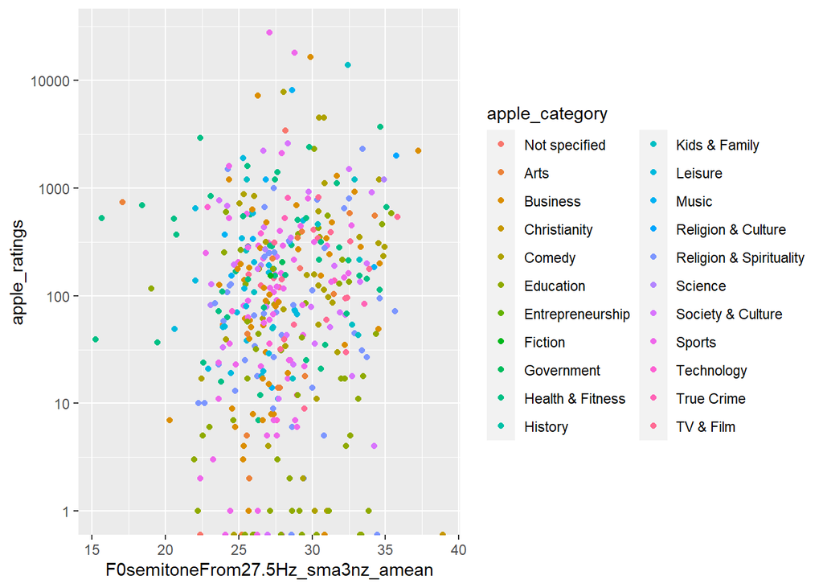

```r
# Fundamental Frequency by Category, by Number of Raters
gg3 <- ggplot(data = data1) +
  geom_point(mapping = aes(x = F0semitoneFrom27.5Hz_sma3nz_amean, y = apple_ratings, color = apple_category)) +
  scale_y_continuous(trans='log10')
gg3
```

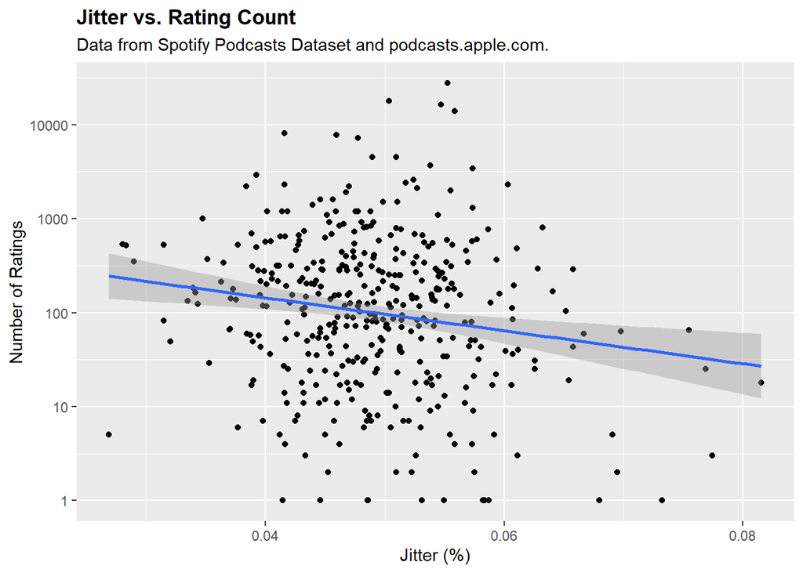

```r
# Jitter by Category, by Number of Raters

# Create the scatterplot with the colored points
gg3 <- ggplot(data = data3, aes(x = jitterLocal_sma3nz_amean, y = apple_ratings)) +
  geom_point() +
  geom_smooth(method = "lm") +
  scale_y_continuous(trans = 'log10') +
  labs(title = "Jitter vs. Rating Count",
       subtitle = "Data from Spotify Podcasts Dataset and podcasts.apple.com.",
       x = "Jitter (%)",
       y = "Number of Ratings") +
  theme(plot.title = element_text(face = "bold"))
gg3
```

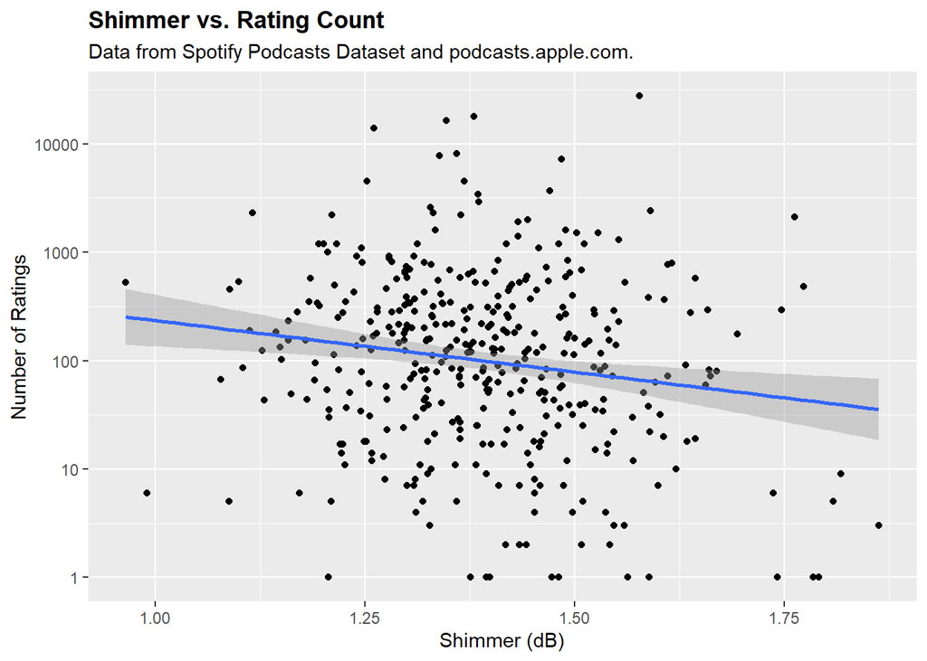

```r
# Shimmer by Category, by Number of Raters

gg3 <- ggplot(data=data3,aes(x=shimmerLocaldB_sma3nz_amean, y=apple_ratings)) +
  geom_point() +
  geom_smooth(method="lm") +
  scale_y_continuous(trans='log10') +
  labs(title = "Shimmer vs. Rating Count",
       subtitle = "Data from Spotify Podcasts Dataset and podcasts.apple.com.",
       x = "Shimmer (dB)",
       y = "Number of Ratings") +
  theme(plot.title=element_text(face = "bold"))

gg3
```

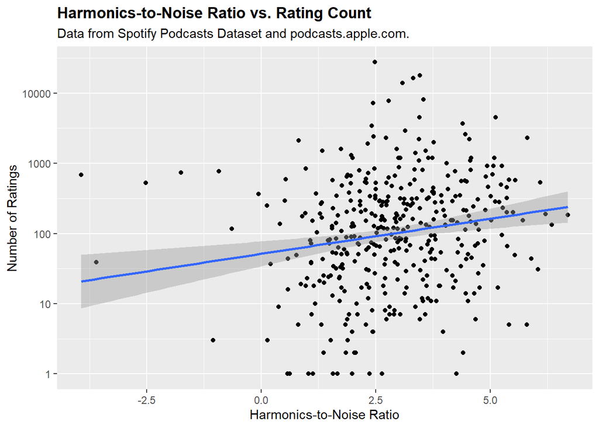

```r
# HNR by Category, by Number of Raters

gg3 <- ggplot(data=data3,aes(x=HNRdBACF_sma3nz_amean, y=apple_ratings)) +
  geom_point() +
  geom_smooth(method="lm") +
  scale_y_continuous(trans='log10') +
  labs(title = "Harmonics-to-Noise Ratio vs. Rating Count",
       subtitle = "Data from Spotify Podcasts Dataset and podcasts.apple.com.",
       x = "Harmonics-to-Noise Ratio",
       y = "Number of Ratings") +
  theme(plot.title=element_text(face = "bold"))

gg3
```

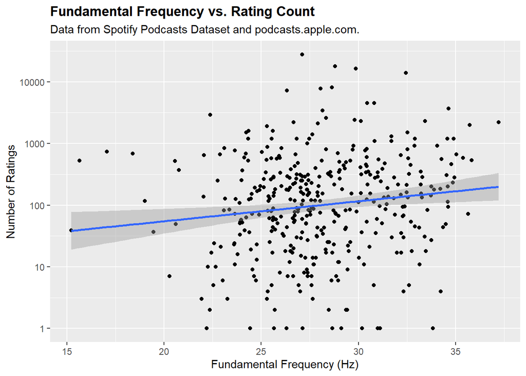

```r
# HNR by Fundamental Frequency, by Number of Raters

gg3 <- ggplot(data=data3,aes(x=F0semitoneFrom27.5Hz_sma3nz_amean, y=apple_ratings)) +
  geom_point() +
  geom_smooth(method="lm") +
  scale_y_continuous(trans='log10') +
  labs(title = "Fundamental Frequency vs. Rating Count",
       subtitle = "Data from Spotify Podcasts Dataset and podcasts.apple.com.",
       x = "Fundamental Frequency (Hz)",
       y = "Number of Ratings") +
  theme(plot.title=element_text(face = "bold"))
gg3
```

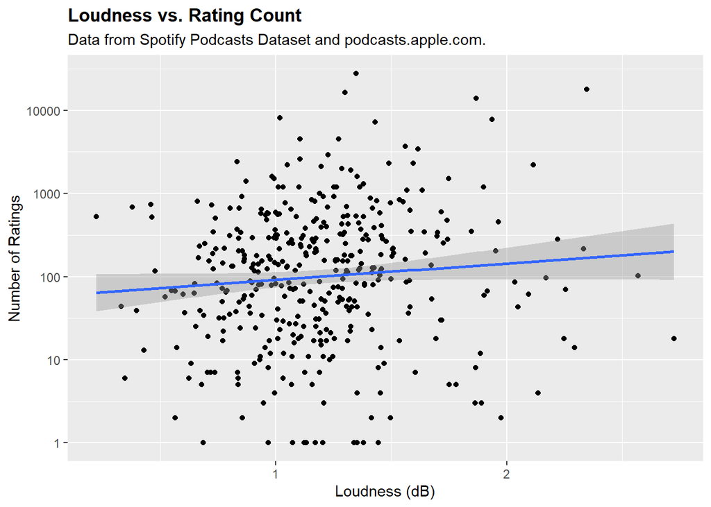

```r
# Loudness by Category, by Number of Raters

gg3 <- ggplot(data=data3,aes(x=loudness_sma3_amean, y=apple_ratings)) +
  geom_point() +
  geom_smooth(method="lm") +
  scale_y_continuous(trans='log10') +
  labs(title = "Loudness vs. Rating Count",
       subtitle = "Data from Spotify Podcasts Dataset and podcasts.apple.com.",
       x = "Loudness (dB)",
       y = "Number of Ratings") +
  theme(plot.title=element_text(face = "bold"))
gg3
```

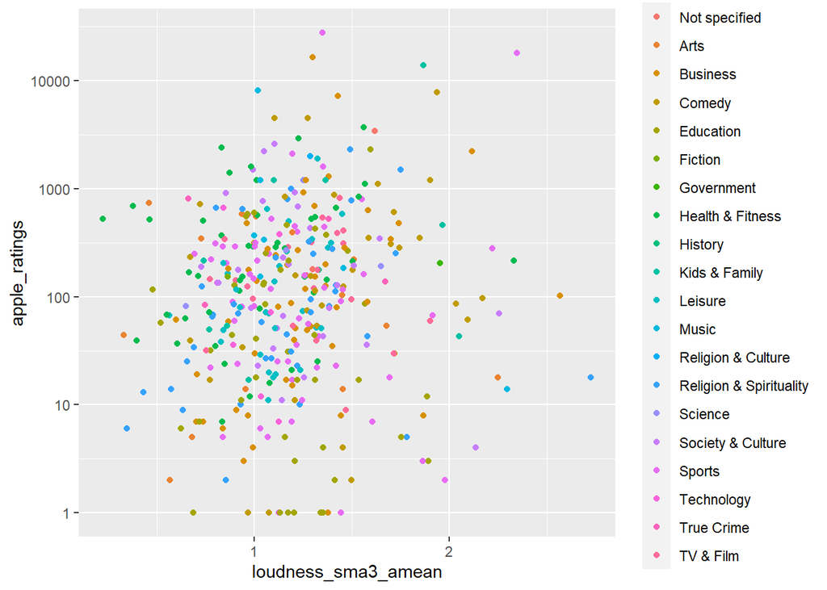

```r
# Loudness by Category, by Number of Raters
gg3 <- ggplot(data = data3) +
  geom_point(mapping = aes(x = loudness_sma3_amean, y = apple_ratings, color = apple_category)) +
  scale_y_continuous(trans='log10')
gg3
```

## Misc. Visualizing the Dataset

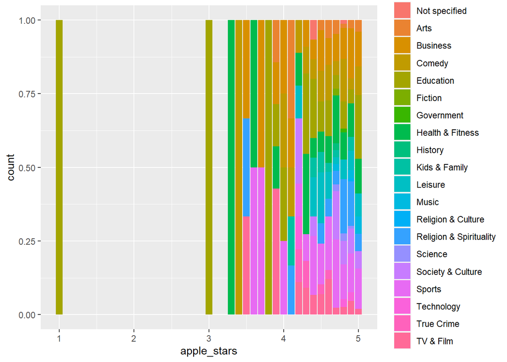

```r
# Apple Stars by Category, By Proportion
gg1 <- ggplot(data = data1) +
  geom_bar(mapping = aes(x = apple_stars, fill = apple_category), position = "fill")
gg1
```

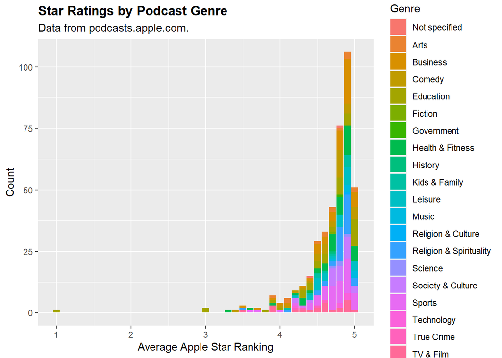

```r
# Apple Stars by Category, by Count
gg2 <- ggplot(data = data1) +
  geom_bar(mapping = aes(x = apple_stars, fill = apple_category)) +
  labs(title = "Star Ratings by Podcast Genre",
       subtitle = "Data from podcasts.apple.com.",
       x = "Average Apple Star Ranking",
       y = "Count") +
  theme(plot.title=element_text(face = "bold")) +
   scale_fill_discrete(name = "Genre")
gg2
```

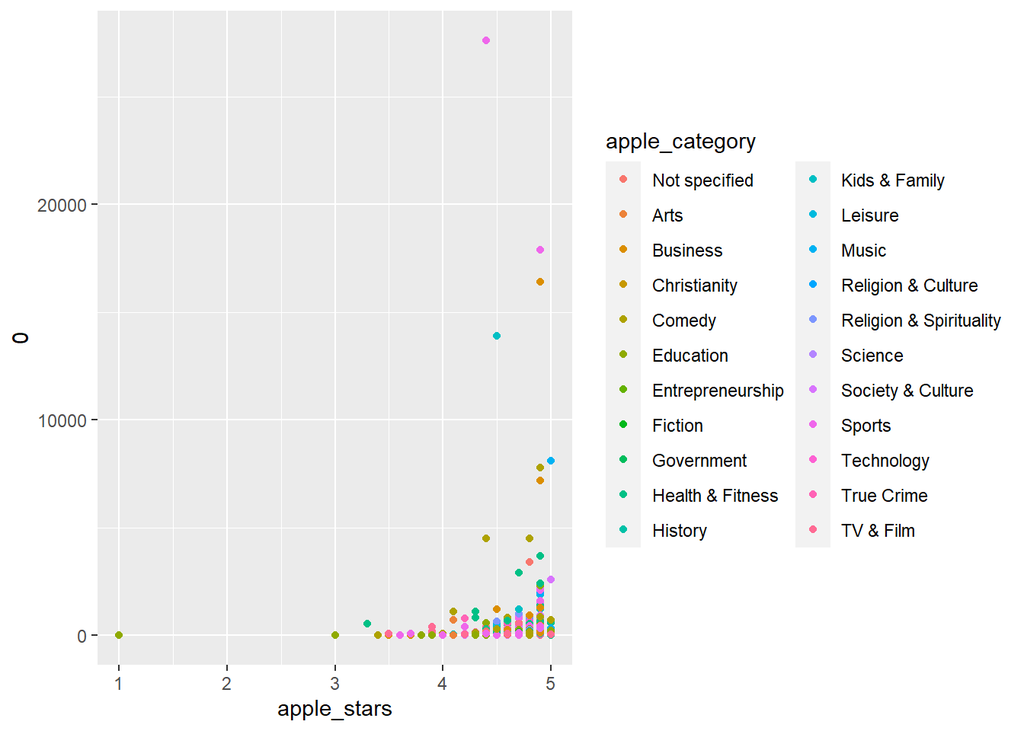

```r
# Apple Stars by Category, by Number of Raters
gg3 <- ggplot(data = data1) +
  geom_point(mapping = aes(x = apple_stars, y = apple_ratings, color = apple_category)) +
  scale_y_continuous(c(0, 30000, 1000))
gg3
```

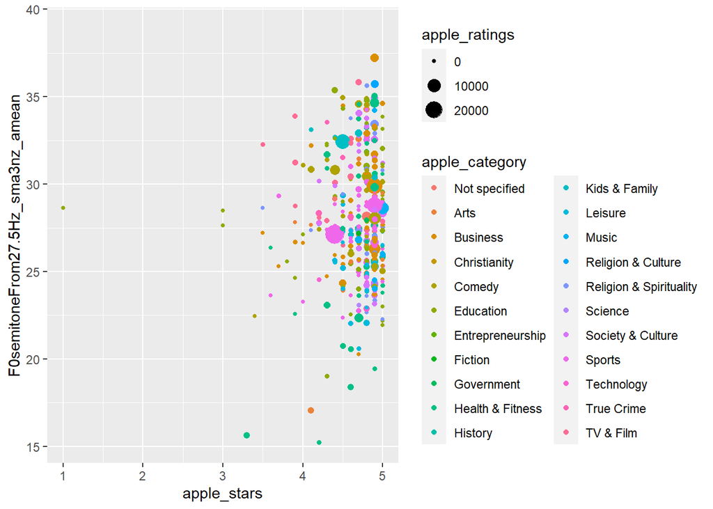

```r
# Bubble Plot of Stars vs. Raters vs. Category
gg_b1 <- ggplot(data = data1, aes(x = apple_stars, y = F0semitoneFrom27.5Hz_sma3nz_amean, size = apple_ratings, color = apple_category)) +
  geom_point()
gg_b1
```

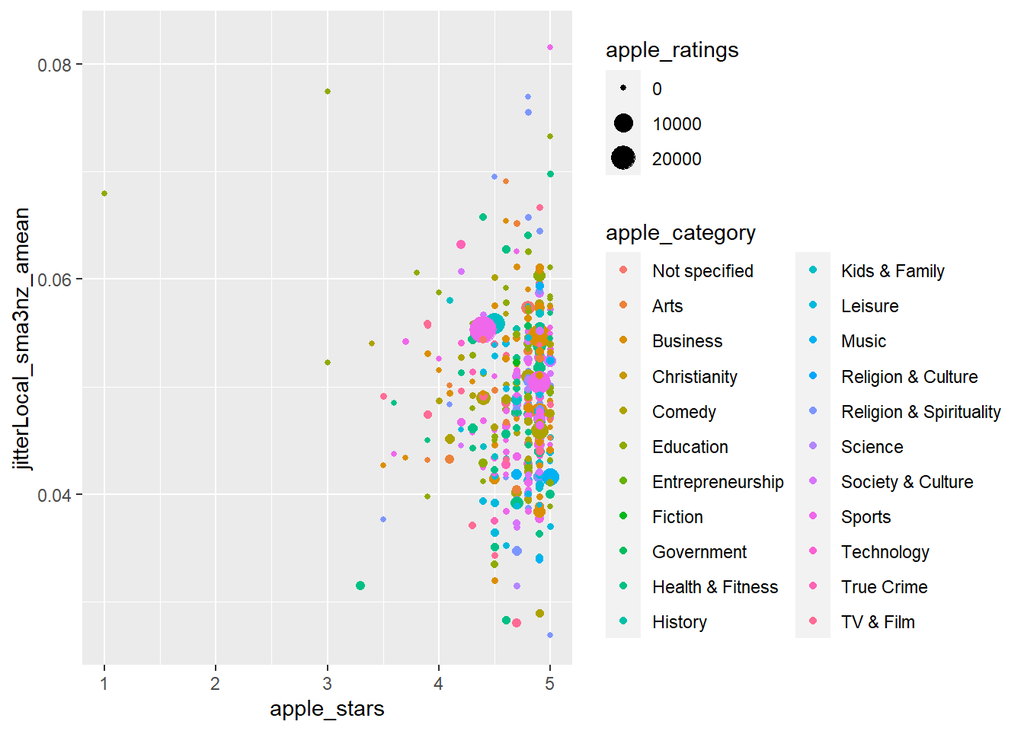

```r
# Bubble Plot of Stars vs. Raters vs. Category
gg_b2 <- ggplot(data = data1, aes(x = apple_stars, y = jitterLocal_sma3nz_amean, size = apple_ratings, color = apple_category)) +
  geom_point()
gg_b2
```

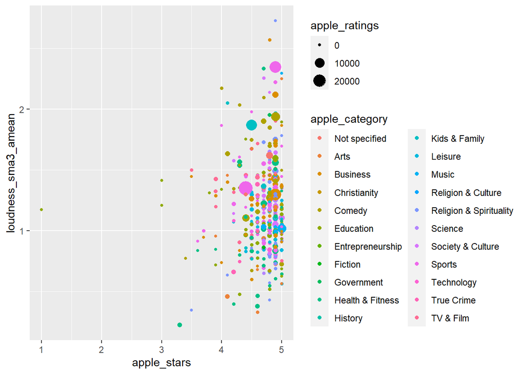

```r
# Bubble Plot of Stars vs. Raters vs. Category
gg_b3 <- ggplot(data = data1, aes(x = apple_stars, y = loudness_sma3_amean, size = apple_ratings, color = apple_category)) +
  geom_point()
gg_b3
```

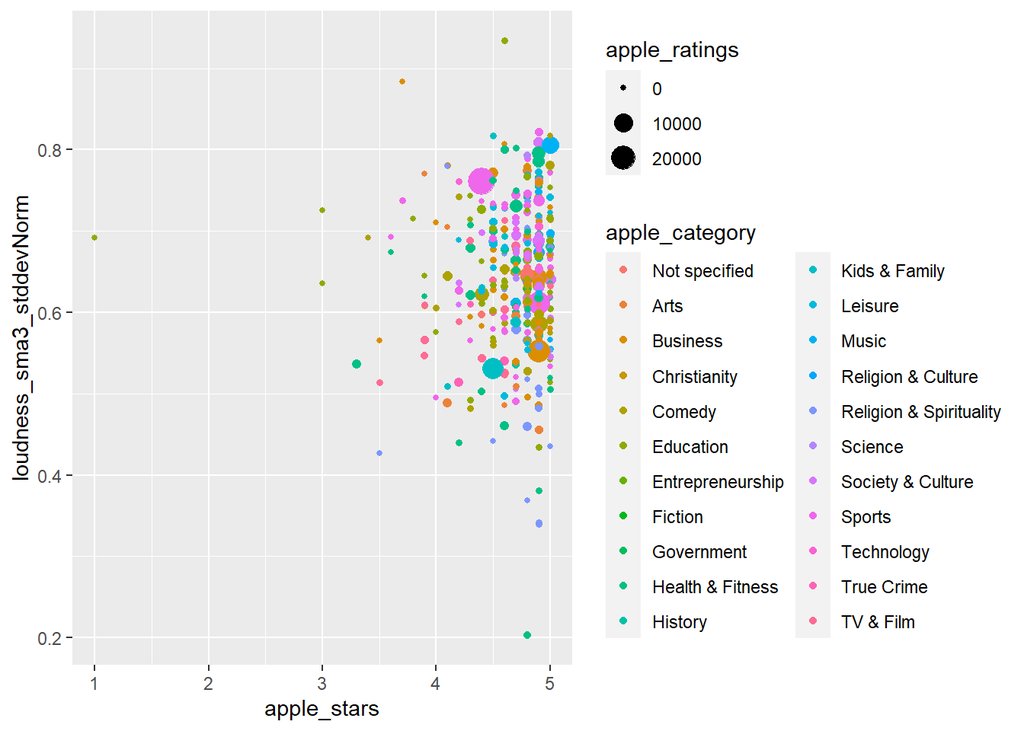

```r
# Bubble Plot of Stars vs. Raters vs. Category
gg_b4 <- ggplot(data = data1, aes(x = apple_stars, y = loudness_sma3_stddevNorm, size = apple_ratings, color = apple_category)) +
  geom_point()
gg_b4
```

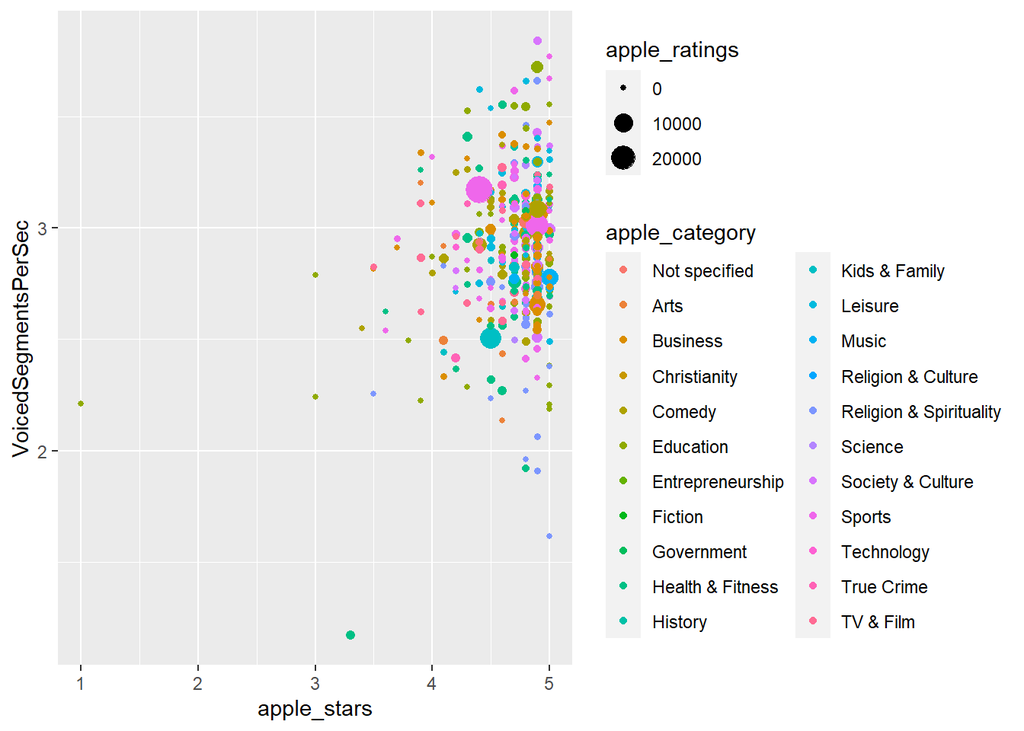

```r
# Bubble Plot of Stars vs. Raters vs. Category
gg_b5 <- ggplot(data = data1, aes(x = apple_stars, y = VoicedSegmentsPerSec, size = apple_ratings, color = apple_category)) +
  geom_point()
gg_b5
```

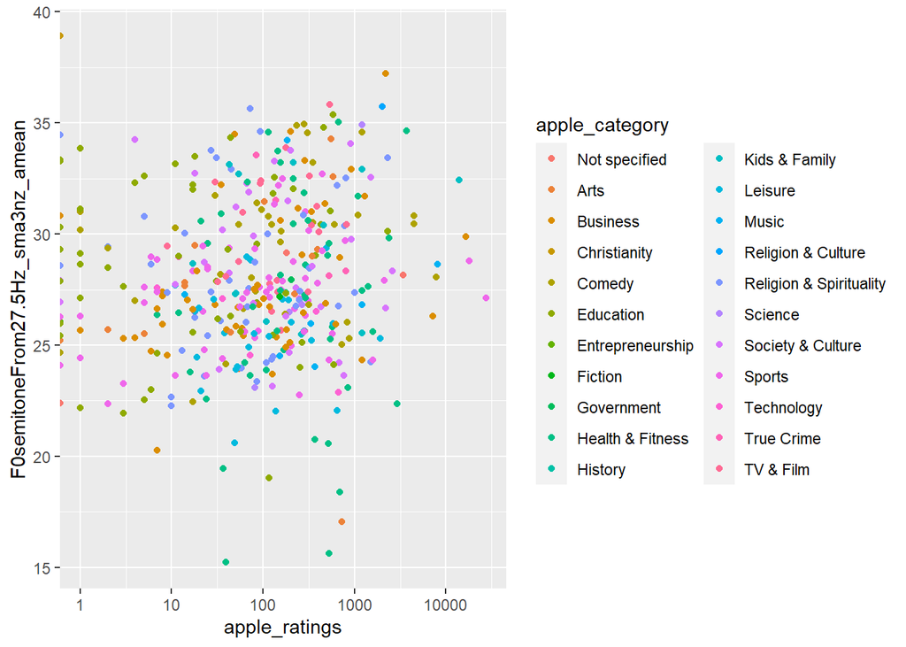

```r
# Bubble Plot of Raters vs. Stars vs. Category
gg_r1 <- ggplot(data = data1, aes(x = apple_ratings, y = F0semitoneFrom27.5Hz_sma3nz_amean, color = apple_category)) +
  geom_point() +
    scale_x_continuous(trans='log10')
gg_r1
```

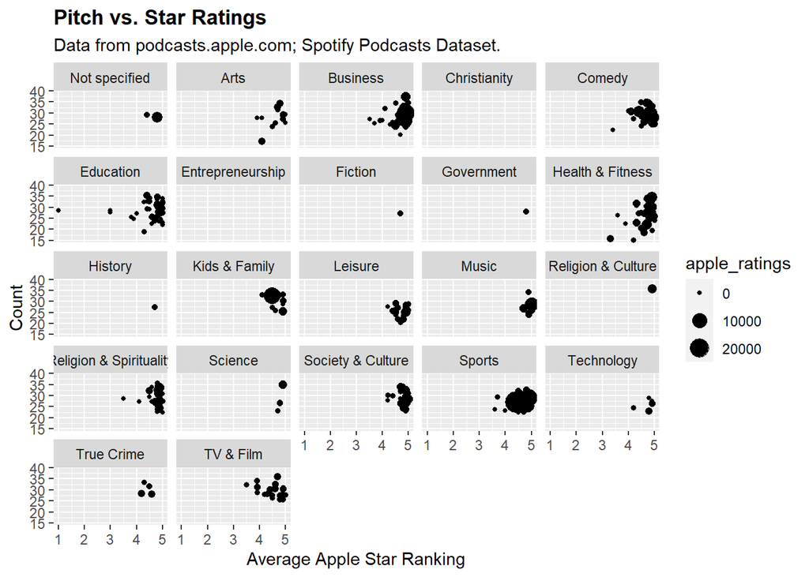

```r
# Facet Wrap of Stars vs. Raters vs. Category for features

gg5 <- ggplot(data = data1) +
  geom_point(mapping = aes(x = apple_stars, y = F0semitoneFrom27.5Hz_sma3nz_amean, size = apple_ratings)) +
  facet_wrap(~ apple_category) +
  labs(title = "Pitch vs. Star Ratings",
       subtitle = "Data from podcasts.apple.com; Spotify Podcasts Dataset.",
       x = "Average Apple Star Ranking",
       y = "Count") +
  theme(plot.title=element_text(face = "bold")) +
   scale_fill_discrete(name = "Number of Raters")
gg5
```

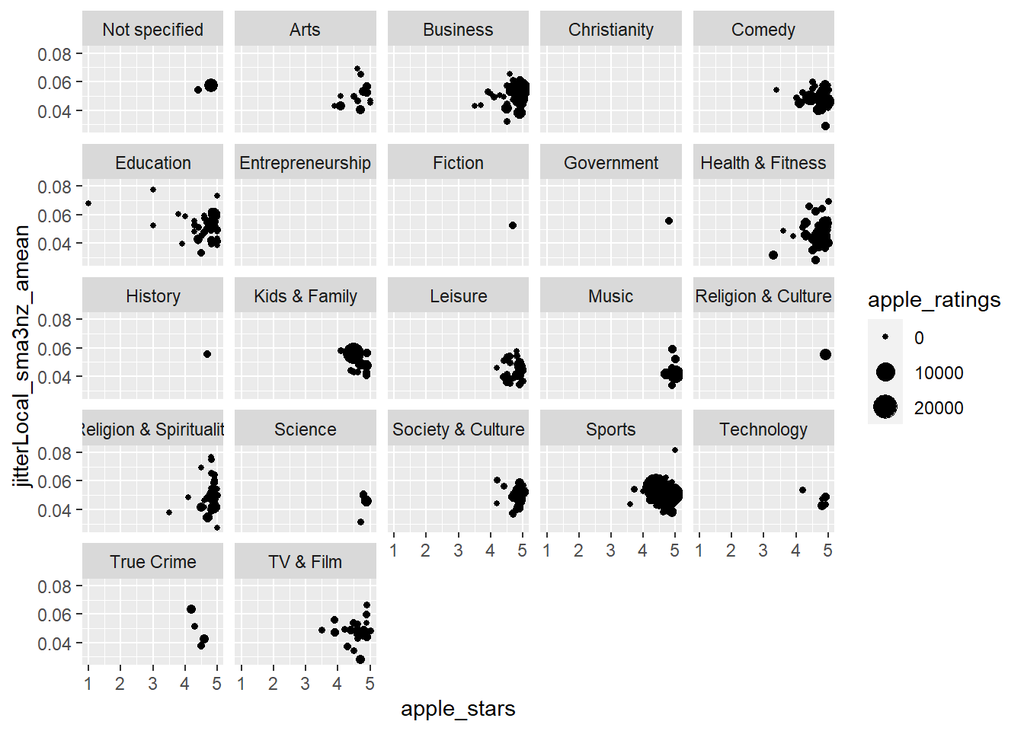

```r
# Facet Wrap of Stars vs. Raters vs. Category for features

gg5 <- ggplot(data = data1) +
  geom_point(mapping = aes(x = apple_stars, y = jitterLocal_sma3nz_amean, size = apple_ratings)) +
  facet_wrap(~ apple_category)
gg5
```

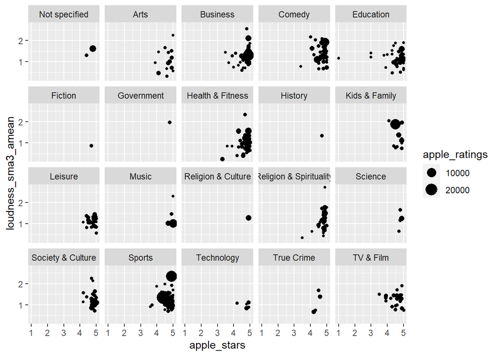

```r
# Facet Wrap of Stars vs. Raters vs. Category for features

gg5 <- ggplot(data = na.omit(data1)) +
  geom_point(mapping = aes(x = apple_stars, y = loudness_sma3_amean, size = apple_ratings)) +
  facet_wrap(~ apple_category)
gg5
```

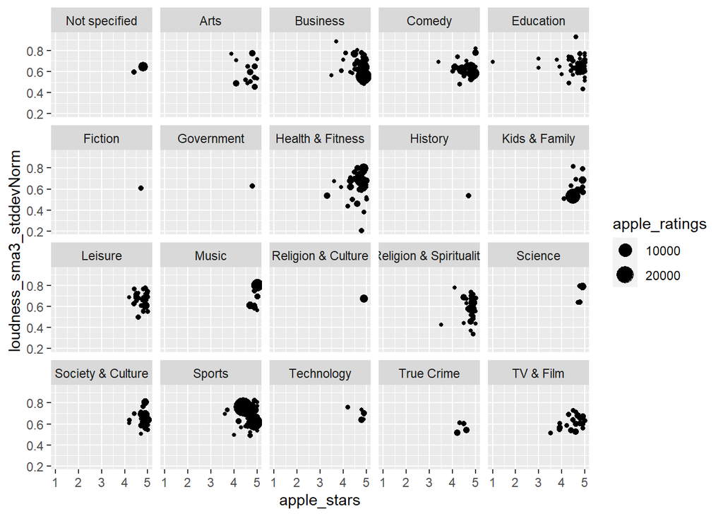

```r
# Facet Wrap of Stars vs. Raters vs. Category for features

gg5 <- ggplot(data = na.omit(data1)) +
  geom_point(mapping = aes(x = apple_stars, y = loudness_sma3_stddevNorm, size = apple_ratings)) +
  facet_wrap(~ apple_category)
gg5
```

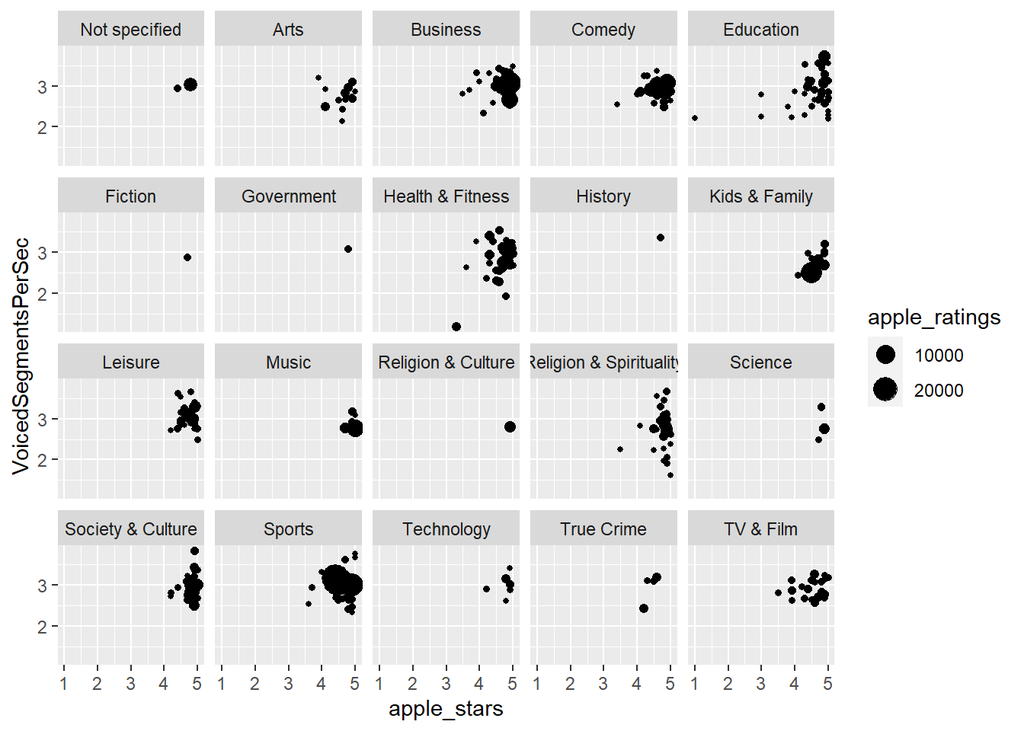

```r
# Facet Wrap of Stars vs. Raters vs. Category for features

gg5 <- ggplot(data = na.omit(data1)) +
  geom_point(mapping = aes(x = apple_stars, y = VoicedSegmentsPerSec, size = apple_ratings)) +
  facet_wrap(~ apple_category)
gg5
```